# My Reproducible Pitch

J

2023-08-20

# Wouldn’t it be nice to …

…Take a dataset and just cycle through the variables and visually see how they are related to one another?

In this example we will use the **mtcars** dataset in R.

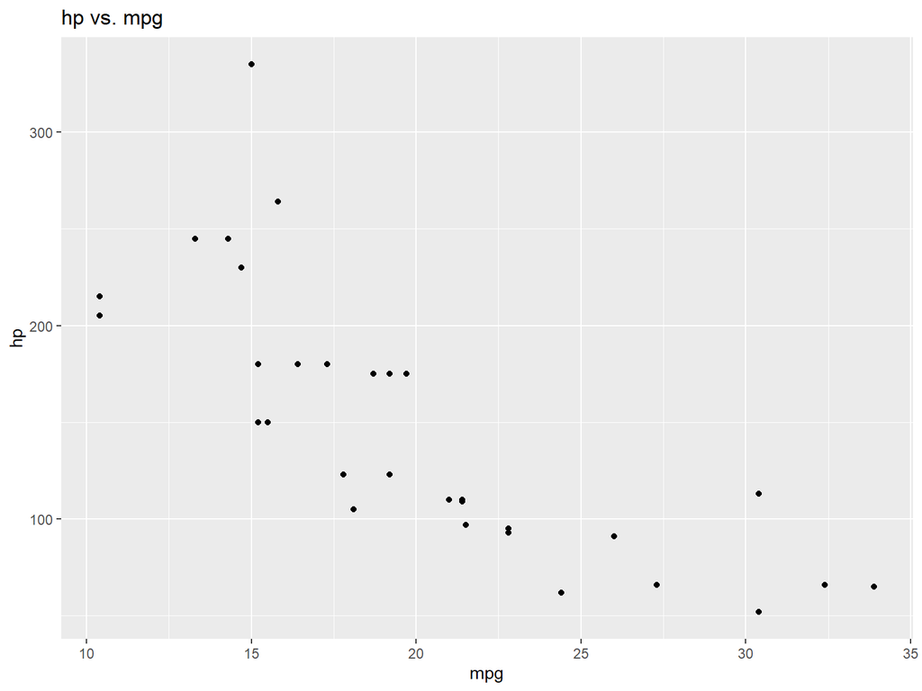

```r
ggplot(data = mtcars, aes(x = mpg, y = hp)) +
     geom_point() + labs(title = "hp vs. mpg")
```

# In R …

We have to select the dataset variables one by one, look at the distribution.

To see how well they correlated together, we need create graph and verify how well a linear model is fitting.

Today, I am presenting you this simple Shiny app that will help you with the data visualization of a dataset.

We will use the mtcars dataset as an example dataset.

Here’s a screenshot to give you an idea of the app.

# Screenshot

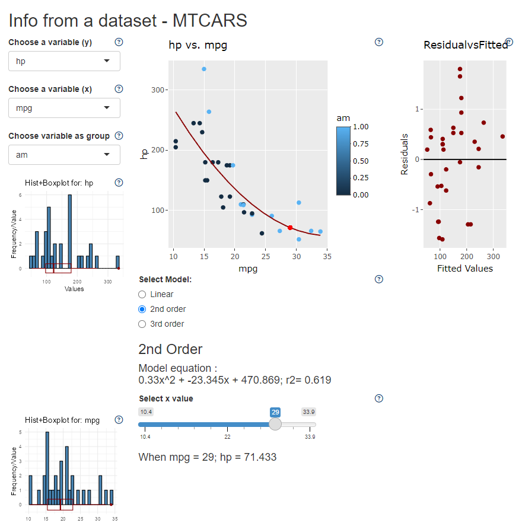

Shiny App Screenshot

# What you can do…

- Select a variable and see an histogram and boxplot distribution.
- Select a second variable and visualize a graph of the relation between the variables.
- Even select a third variable to add color to the points of the graph.
- Select a linear, 2nd or third order model to apply to the selected variables.
- Obtain the equation for the model used
- Select a value for the x variable and know directly what is the result obtain in y for the selected model.
- See how well the selected model fits with the Adjusted R square (r2) value and a graph of the residual.
- And also, get help on the different parts of the app.

Only with a few selections…

Try it here https://jdata01.shinyapps.io/Dataset_info/